# Forecasting Foreign Aid Amounts

This is a walk through report explaining the process of using forecast methodologies and apply those methodologies to financial foreign aid. This walk through is broken up into different sections:

- Introduction
- The Data Workflow
  - Data Import
  - Exploratory Data Analysis
- Forecast
  - Methodologies
  - Implementation
- Conclusions

# Introduction

Developing countries face challenges in accessing up-to-date information about aid, development, and humanitarian flows. This information is needed to plan and manage resources effectively. There is a large movement which allows different stakeholders to publish data on development cooperation activities. The International Aid Transparency Initiative [IATI](http://www.aidtransparency.net/) manages and provides the standard that donors and recipient countries, civil society organizations, and others use to publish and consume data on development cooperation activities.

Assumptions:

- All values are in USD
- Amounts reported by donors are accurate

# Data Workflow

The first step of any analysis is to import the necessary packages. Packages used in this analysis are below.

```r
library(ggplot2) #static visualization
library(dplyr) #data manipulation and connect to database
library(knitr)
library("devtools") #needed to install plotly if you don't have it already

library(plotly) #interactive visualization
```

## Importing the CSV

The data was downloaded via the IATI API. The resulting csv was imported into memory to quickly view.

[output not shown]

```r
transactions <- read.csv("transaction.csv", header=TRUE)
nrow(transactions)
```

The number of rows is quite large so the first step is to cut it down to only include transactions that are disbursments and commitments. In the transaction.type, fields with C, D, 2, or 3 are commitments and disbursements. First step is to subset the data to see how many rows of data are in the file.

```r
data <- subset(transactions, transaction.type =="C" | transaction.type =="D" | transaction.type ==2 | transaction.type == 3)
nrow(data)
```

```
## [1] 155147
```

```r
nrow(transactions) - nrow(data)
```

```
## [1] 46558
```

The next step is to filter out only the necessary fields. Currently, there are 74, the key fields necessary are:

- transaction date
- default currency
- transaction value
- IATI identifier
- Reporting Org
- Title
- Start Planned
- End Planned
- Start Actual
- End Actual
- Recipient Country
- Recipient Country Code
- Sector

```r
data <- data[c("transaction.date","transaction.value", "iati.identifier", "reporting.org", "title", "start.planned", "end.planned", "start.actual", "end.actual", "recipient.country","recipient.country.code", "sector")]
```

The next step is to remove data that has multiple countries in the transactions, see example below.

```r
example.bad <- subset(data, recipient.country =="Pakistan;India;Nepal")
knitr::kable(head(example.bad))
```

|  | transaction.date | transaction.value | iati.identifier | reporting.org | title | start.planned | end.planned | start.actual | end.actual | recipient.country | recipient.country.code | sector |
| --- | --- | --- | --- | --- | --- | --- | --- | --- | --- | --- | --- | --- |
| 199192 | 2014-01-31 | 268900 | XM-DAC-301-2-107617-001 | International Development Research Centre | Bringing Women’s Voices into the Mainstream: A Media Research Fellowship on Militarization and Women in South Asia |  | 2016-01-17 | 2014-01-17 |  | Pakistan;India;Nepal | PK;IN;NP | ;Women’s equality organisations and institutions * |

I could split the transaction into three separate transactions and divide it equally amongst the three recipients, but this would be disengenious to the data and a data quality issue. To limit the scope of this study, the scope is limited to only transactions that are directly to a singular country.

```r
data$recipient.country<- as.character(data$recipient.country)
data$recipient.country[data$recipient.country == "Lao People'S Democratic Republic"] <- "Laos"


data <- subset(data, recipient.country=="Chad"|recipient.country=="Ethiopia"|recipient.country=="Nepal"|recipient.country=="Honduras"|recipient.country=="Senegal"|recipient.country=="Haiti"|recipient.country=="Burkina Faso"| recipient.country=="Burkina Faso"|recipient.country=="Tanzania, United Republic Of"|recipient.country=="Laos"|recipient.country=="Malawi"|recipient.country=="Moldova, Republic of"| recipient.country=="Madagascar"|recipient.country=="Uganda"|recipient.country=="Timor-Leste"|recipient.country=="Congo, The Democratic Republic Of The"|recipient.country=="Kyrgyzstan"|recipient.country.code=="CI")

data <- subset(data, transaction.value!="NA")
data <- subset(data, transaction.date!="")
```

Write data to csv and import it to sqlite.

```r
write.csv(data, file = "transaction.clean.csv", row.names=TRUE, na="")
```

After doing this you can then create an SQLite database and import the dataset you just created. Below is the code typed into the command line. There are a lot of interfaces out there that allows you to manage databases without needing to know the command line.

```
$ sqlite3 data.db # Create your database
$.databases       # Show databases to make sure it works
$.mode csv
$.import <filename> <tablename>
# Where filename is the name of the csv & tablename is the name of the new database table
$.quit
```

## Connect to the Database

Connect to the database and the appropriate table

[output not shown]

```
db <- src_sqlite('transactions.db', create = FALSE)
db

data.clean <- tbl(db, 'transclean')
```

### Preview the data

```r
head_ <- function(x, n = 5) head(x, n)
kable(head_(data.clean))
```

| transaction.date | transaction.value | iati.identifier | reporting.org | title | start.planned | end.planned | start.actual | end.actual | recipient.country | recipient.country.code | sector |
| --- | --- | --- | --- | --- | --- | --- | --- | --- | --- | --- | --- |
| 12/28/2007 | -249.35701 | SE-0-SE-6-7430002201-TZA-16030 | Sweden | SHIA ram syd 2005-06 |  |  | 01/01/2005 | 06/28/2007 | Tanzania United Republic Of | TZ | Housing policy and administrative management |
| 12/28/2006 | 7141.019624 | SE-0-SE-6-7430002201-TZA-16030 | Sweden | SHIA ram syd 2005-06 |  |  | 01/01/2005 | 06/28/2007 | Tanzania United Republic Of | TZ | Housing policy and administrative management |
| 12/28/2005 | 7060.542797 | SE-0-SE-6-7430002201-TZA-16030 | Sweden | SHIA ram syd 2005-06 |  |  | 01/01/2005 | 06/28/2007 | Tanzania United Republic Of | TZ | Housing policy and administrative management |
| 01/01/2005 | 14544.59076 | SE-0-SE-6-7430002201-TZA-16030 | Sweden | SHIA ram syd 2005-06 |  |  | 01/01/2005 | 06/28/2007 | Tanzania United Republic Of | TZ | Housing policy and administrative management |
| 09/30/2013 | 8624.96 | US-10-BF-EG-d6f10d66-1737-4a40-ab52-52874b457d86 | United States | Volunteer Pre-Service Training |  |  | 10/01/2012 | 09/30/2013 | Burkina Faso | BF |  |

## Exploratory Data Analysis

```r
#actions count per country

#query
q <- data.clean %>% select(recipient.country) %>%
  group_by(recipient.country) %>%
  summarise(transactions = sum(transaction.value)) %>%
  arrange(-transactions)

#pass query to database
q <- collect(q)

knitr::kable(q)
```

| recipient.country | transactions |
| --- | --- |
| Tanzania United Republic Of | 62514909042 |
| Nepal | 52899544876 |
| Uganda | 52043547611 |
| Ethiopia | 46018144080 |
| Haiti | 40415034469 |
| Congo The Democratic Republic Of The | 26985817746 |
| Laos | 25325523547 |
| Burkina Faso | 20875247489 |
| Senegal | 17023544000 |
| Malawi | 15849225621 |
| Cote D’Ivoire | 9552306180 |
| Timor-Leste | 8621480376 |
| Honduras | 8273773282 |
| Madagascar | 6973336643 |
| Kyrgyzstan | 5355120280 |
| Chad | 5237509441 |

```r
#plot
plt <- ggplot(q, aes(recipient.country, transactions)) +
                geom_bar(stat = 'identity') +
                theme_minimal() + theme(axis.text.x = element_text(angle = 45, hjust = 1))

#pass to plotly
py <- plotly()
py$ggplotly(plt, session='knitr')
```

[interactive chart not shown]

# Forecast

### Extracting Dates

The data provided does not fit the standard date format for SQLite, it cannot consume MM/DD/YYYY and has to remove the slashes. We have a few options to remedy this:

- Create a new column in the SQL database, and reinsert the data with the formatted date statements
- Create a new table and INSERT the formatted date into the original column name
- Generate a SELECT wrapper using dplyr that formats the dates.

To illustrate using R, I will use dplyr. This is not necessarily the most optimal approach. Here I select substrings of the date fields, with SUBSTR and concatenate them with ||.

```r
data.clean <- tbl(db, sql('SELECT "transaction.value" AS transvalue,
                    SUBSTR("transaction.date", 7, 4) || "-" ||
                    SUBSTR("transaction.date", 4, 2) || "-" ||
                    SUBSTR("transaction.date", 1, 2) as "transactiondate", "iati.identifier" AS id, "reporting.org" AS "reporter", title,
                    SUBSTR("start.planned", 7, 4) || "-" ||
                    SUBSTR("start.planned", 4, 2) || "-" ||
                    SUBSTR("start.planned", 1, 2) as "startplanned",
                    SUBSTR("end.planned", 7, 4) || "-" ||
                    SUBSTR("end.planned", 4, 2) || "-" ||
                    SUBSTR("end.planned", 1, 2) as "endplanned",
                    SUBSTR("start.actual", 7, 4) || "-" ||
                    SUBSTR("start.actual", 4, 2) || "-" ||
                    SUBSTR("start.actual", 1, 2) as "startactual",
                    SUBSTR("end.actual", 7, 4) || "-" ||
                    SUBSTR("end.actual", 4, 2) || "-" ||
                    SUBSTR("end.actual", 1, 2) as "endactual",
                    "recipient.country" AS recipient, "recipient.country.code" AS countrycode, sector
                    FROM transclean'))
```

### Pull out the year using strftime

The command strftime allows you to pull out specific time periods. What is being done in the commands below is capturing the year, creating a new column with only the year, and then grouping the projects by year created. A graphic is then produced.

```r
#created year pulled out and new column created
q <- data.clean %>% mutate(year = strftime('%Y', transactiondate))%>%
  group_by(year) %>% summarise(transaction.value.year= sum(transvalue))

#run query
q <- collect(q)

plt <- ggplot(na.omit(q), aes(year, transaction.value.year)) +
  geom_bar(stat='identity') +
  theme_minimal() + theme(axis.text.x = element_text(angle = 45, hjust = 1))

py <- plotly()
py$ggplotly(plt, session='knitr')
```

[interactive chart not shown]

What the above graphic shows is that the year 2012, there was a large spike of transaction amounts in 2012. To determine what caused the spike in 2012, the year 2011 has to be investiated since aid budgets are on a yearly basis. Some world events in 2011 that could have increased financial aid amounts is the Arab Spring, South Sudan secedes from Sudan, and Nepalese assembly writing the constitution and opening the country. Financial aid amounts could also be high in 2012 if the amounts are from natural disasters. For example, the Haiti earthquan in late 2010 should cause an increase in 2011 and then a much larger increase in 2012. After 2012, there should be a tapering of aid amounts to Haiti.

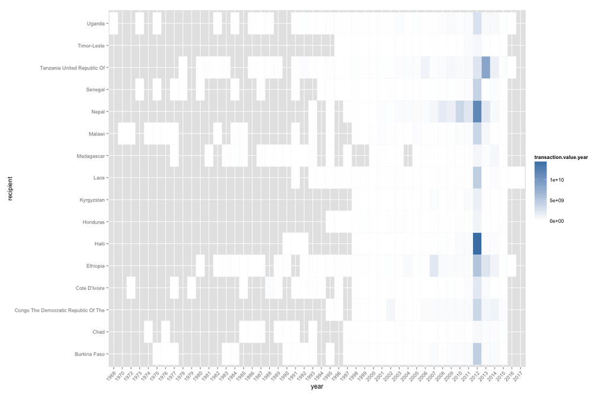

```r
q <- data.clean %>% mutate(year = strftime('%Y', transactiondate))%>%
  group_by(year, recipient) %>% summarise(transaction.value.year= sum(transvalue))

q <- collect(q)

plt <- ggplot(na.omit(q), aes(year, recipient)) +
  geom_tile(aes(fill=transaction.value.year), colour = "white") +
  scale_fill_gradient(low = "white", high = "steelblue")+
  theme(axis.text.x = element_text(angle = 45, hjust = 1))
```

The graph above shows just that. There was a huge spike in Haiti in 2012 and then a leveling off. Though the data shows that in 2012 there was just a general increase in aid transactions overall. This could be a result of governments recovering from the 2008 financial crisis and beginning to make more commitments abroad. The three countries with the most consistent amount of funding seems to be Nepal, Tanzania, and Ethiopia.

## Scaled Transaction Values

One the issues with financial aid transactions is that transaction amounts are often reactionary to world events. As a result, there are huge spikes of financial aid transactions after disasters, food shortages, or other world events. These spikes and lows are similar to stocks within the stock market; however, stock market values can be adjusted and forecasted using logarithm functions. Financial aid transactions don’t follow the same logarithmic exponential form. Another way to forecast is to find the average of a certain time period and then determine if the amount is going to be above or below the average.

The issue with the average is that with the spikes and lows in financial aid amounts, the average will always be low number. See the below example with Nepal.

```r
q <- data.clean %>% select(transvalue, recipient, transactiondate) %>%
          filter(recipient == "Nepal") %>%
          mutate(year = strftime('%Y', transactiondate))

q <- collect(q)

nepal.ave <- subset(q, q$year>=2009)

nepal.ave$transvalue <- as.numeric(nepal.ave$transvalue)

mean(nepal.ave$transvalue)
```

```
## [1] 5780023
```

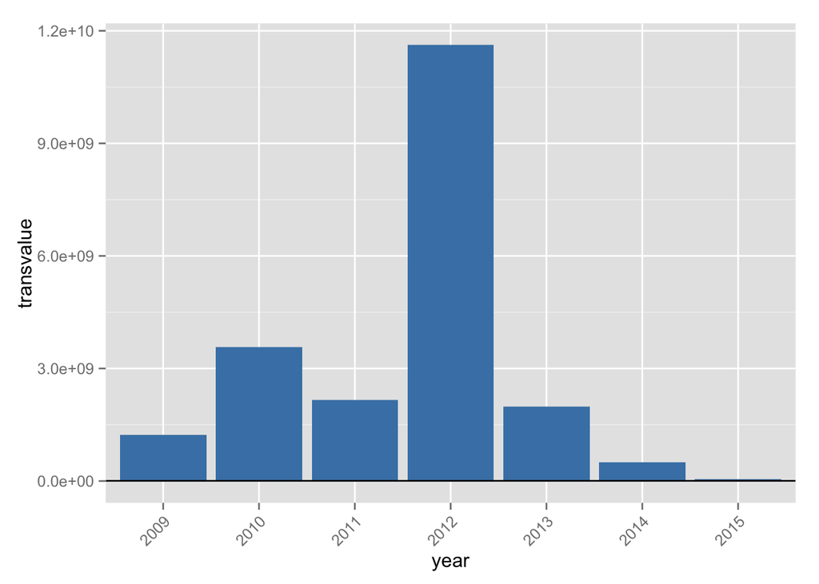

```r
plt <- ggplot(na.omit(nepal.ave), aes(year, transvalue)) +
  geom_bar(stat='identity', fill = "steelblue") +
  geom_abline(intercept = 5780023)+
  theme(axis.text.x = element_text(angle = 45, hjust = 1))

plt
```

One way to account for this is to scale the values, take the average of the scaled values and plot.

```r
nepal.ave$scalevalues <- scale(nepal.ave$transvalue)

mean(nepal.ave$scalevalues)
```

```
## [1] 2.664344e-18
```

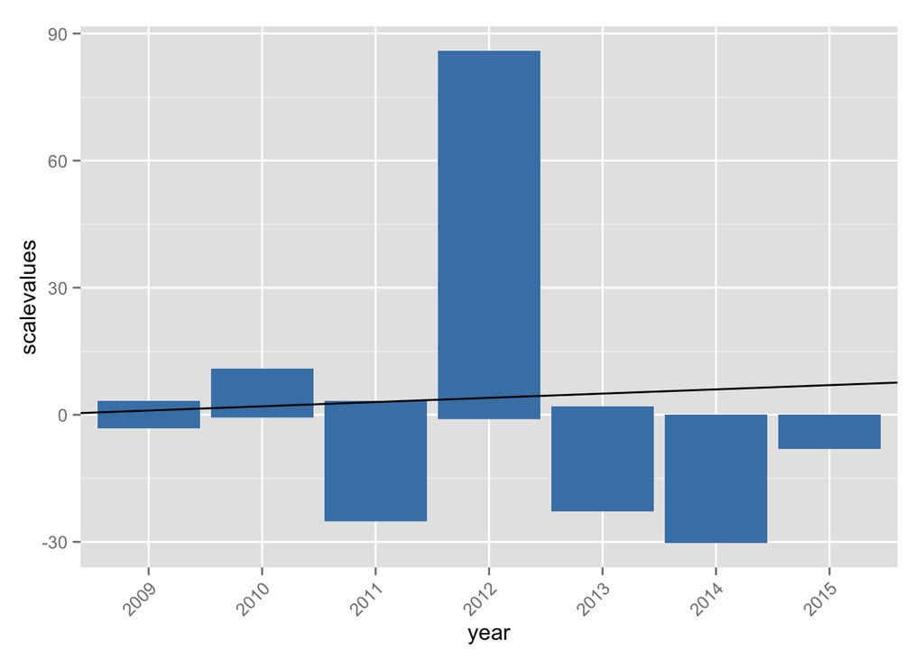

```r
plt <- ggplot(na.omit(nepal.ave), aes(year, scalevalues)) +
  geom_bar(stat='identity', fill = "steelblue") +
  geom_abline(intercept = 2.664344e-18)+
  theme(axis.text.x = element_text(angle = 45, hjust = 1))

plt
```

The increase of aive overtime is even more apparent when looking at the entire history of foreign financial assistance to Nepal.

```r
q <- data.clean %>% select(transvalue, recipient, transactiondate) %>%
          filter(recipient == "Nepal") %>%
          mutate(year = strftime('%Y', transactiondate))

nepal <- collect(q)

nepal$transvalue <- as.numeric(nepal$transvalue)

nepal$scalevalues <- scale(nepal$transvalue)

mean(nepal$scalevalues)
```

```
## [1] -2.111368e-18
```

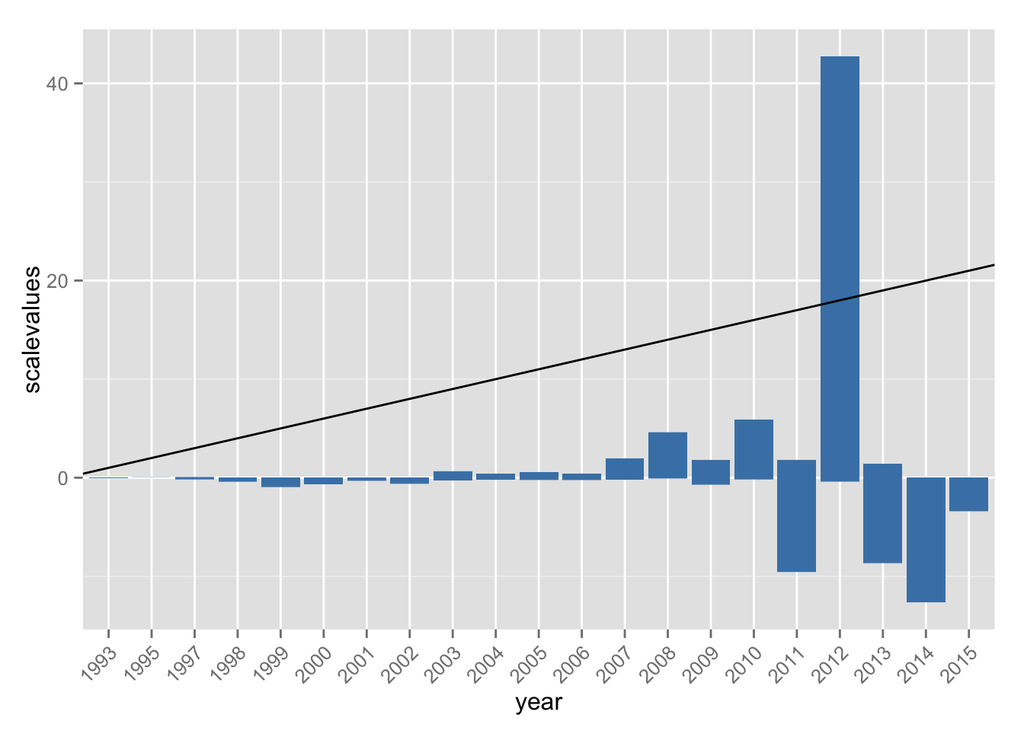

```r
plt <- ggplot(na.omit(nepal), aes(year, scalevalues)) +
  geom_bar(stat='identity', fill = "steelblue") +
  geom_abline(intercept = 2.664344e-18)+
  theme(axis.text.x = element_text(angle = 45, hjust = 1))

plt
```

The above methodology will be applied to each country and a conclusion will be made as to if aid will increase, decrease, or stay about the same in the countries selected which are:

- Burkina Faso
- Chad
- Congo
- Cote D’Ivoire
- Ethiopia
- Haiti
- Honduras
- Kyrgyzstan
- Laos
- Madagascar
- Malawi
- Nepal
- Senegal
- Tanzania
- Timor-Leste
- Uganda

### Burkina Faso

```r
q <- data.clean %>% select(transvalue, recipient, transactiondate) %>%
          filter(recipient == "Burkina Faso") %>%
          mutate(year = strftime('%Y', transactiondate))

burkina <- collect(q)

burkina$transvalue <- as.numeric(burkina$transvalue)

burkina$scalevalues <- scale(burkina$transvalue)

mean(burkina$scalevalues)
```

```
## [1] 2.913786e-18
```

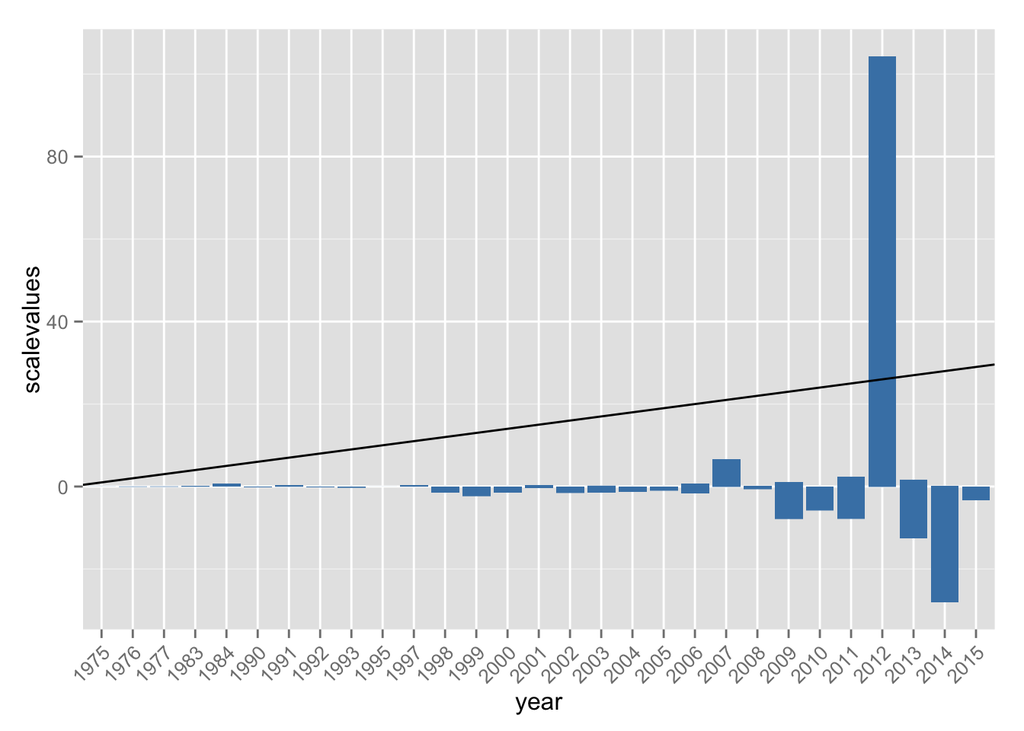

```r
plt <- ggplot(na.omit(burkina), aes(year, scalevalues)) +
  geom_bar(stat='identity', fill = "steelblue") +
  geom_abline(intercept = 2.913786e-18)+
  theme(axis.text.x = element_text(angle = 45, hjust = 1))

plt
```

There is a large spike in 2012 due to the overall large spike across all countries studied, There was a decrease in 2013 and 2014. Expect 2015 values and 2016 values to be larger than 2014.

### Chad

```r
q <- data.clean %>% select(transvalue, recipient, transactiondate) %>%
          filter(recipient == "Chad") %>%
          mutate(year = strftime('%Y', transactiondate))

chad<- collect(q)

chad$transvalue <- as.numeric(chad$transvalue)

chad$scalevalues <- scale(chad$transvalue)

mean(chad$scalevalues)
```

```
## [1] 1.6914e-17
```

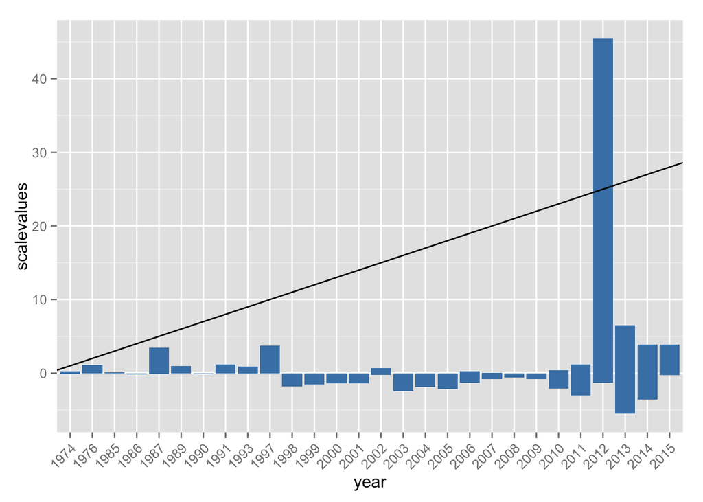

```r
plt <- ggplot(na.omit(chad), aes(year, scalevalues)) +
  geom_bar(stat='identity', fill = "steelblue") +
  geom_abline(intercept = 1.6914e-17)+
  theme(axis.text.x = element_text(angle = 45, hjust = 1))

plt
```

```r
q <- data.clean %>% select(transvalue, recipient, transactiondate) %>%
          filter(recipient == "Congo The Democratic Republic Of The") %>%
          mutate(year = strftime('%Y', transactiondate))

congo<- collect(q)

congo$transvalue <- as.numeric(congo$transvalue)

congo$scalevalues <- scale(congo$transvalue)

mean(congo$scalevalues)
```

```
## [1] -4.773688e-18
```

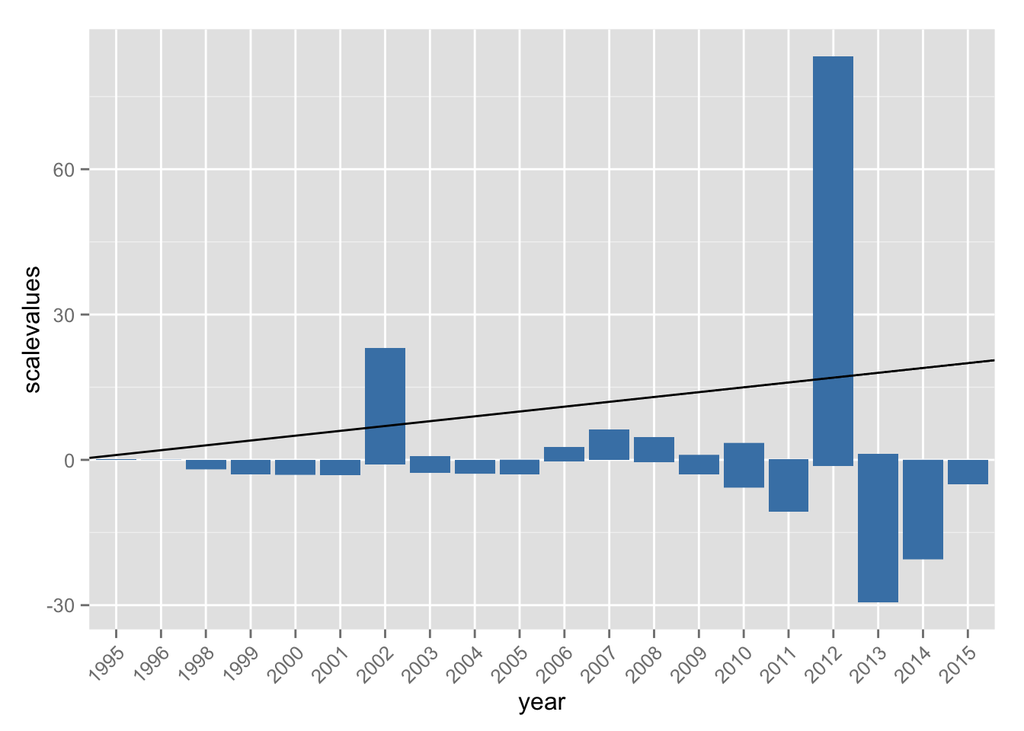

```r
plt <- ggplot(na.omit(congo), aes(year, scalevalues)) +
  geom_bar(stat='identity', fill = "steelblue") +
  geom_abline(intercept = -4.773688e-18)+
  theme(axis.text.x = element_text(angle = 45, hjust = 1))

plt
```

### Cote D’Ivoire

```r
q <- data.clean %>% select(transvalue, recipient, transactiondate) %>%
          filter(recipient == "Cote D'Ivoire") %>%
          mutate(year = strftime('%Y', transactiondate))

civ<- collect(q)

civ$transvalue <- as.numeric(civ$transvalue)

civ$scalevalues <- scale(civ$transvalue)

mean(civ$scalevalues)
```

```
## [1] 1.103739e-17
```

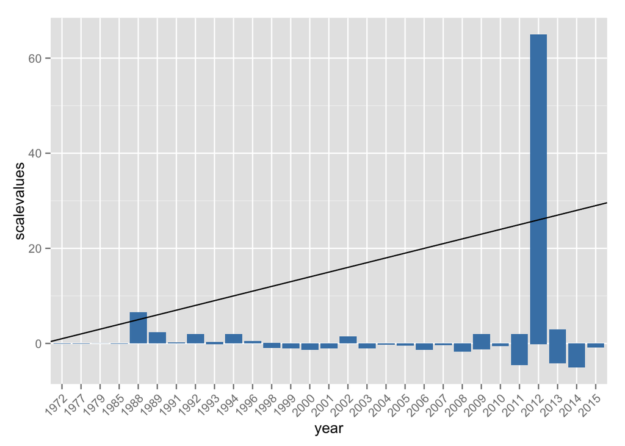

```r
plt <- ggplot(na.omit(civ), aes(year, scalevalues)) +
  geom_bar(stat='identity', fill = "steelblue") +
  geom_abline(intercept = 1.103739e-17)+
  theme(axis.text.x = element_text(angle = 45, hjust = 1))

plt
```

Incredibly large spike in 2012 with decreases over the next three years. This large spike is due to the Civil War experienced in the country. Expect the aid amount to increase relative to 2015 and 2016 with a more stable nation.

### Ethiopia

```r
q <- data.clean %>% select(transvalue, recipient, transactiondate) %>%
          filter(recipient == "Ethiopia") %>%
          mutate(year = strftime('%Y', transactiondate))

ethiopia<- collect(q)

ethiopia$transvalue <- as.numeric(ethiopia$transvalue)

ethiopia$scalevalues <- scale(ethiopia$transvalue)

mean(ethiopia$scalevalues)
```

```
## [1] 3.986141e-18
```

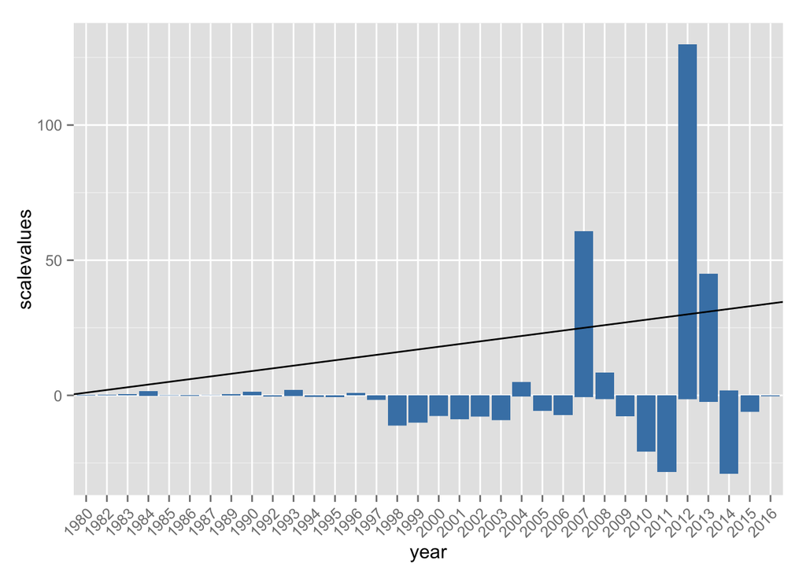

```r
plt <- ggplot(na.omit(ethiopia), aes(year, scalevalues)) +
  geom_bar(stat='identity', fill = "steelblue") +
  geom_abline(intercept = 3.986141e-18)+
  theme(axis.text.x = element_text(angle = 45, hjust = 1))

plt
```

There are large spikes of aid in 2007, 2012, and 2013. These large spikes seem to have three years of small amounts of aid flowing into the country. The most recent large spike was in 2013 so can expect 2015 to have a decreased amount of funding, with an increase in 2016.

### Haiti

```r
q <- data.clean %>% select(transvalue, recipient, transactiondate) %>%
          filter(recipient == "Haiti") %>%
          mutate(year = strftime('%Y', transactiondate))

haiti<- collect(q)

haiti$transvalue <- as.numeric(haiti$transvalue)

haiti$scalevalues <- scale(haiti$transvalue)

mean(haiti$scalevalues)
```

```
## [1] -2.101609e-18
```

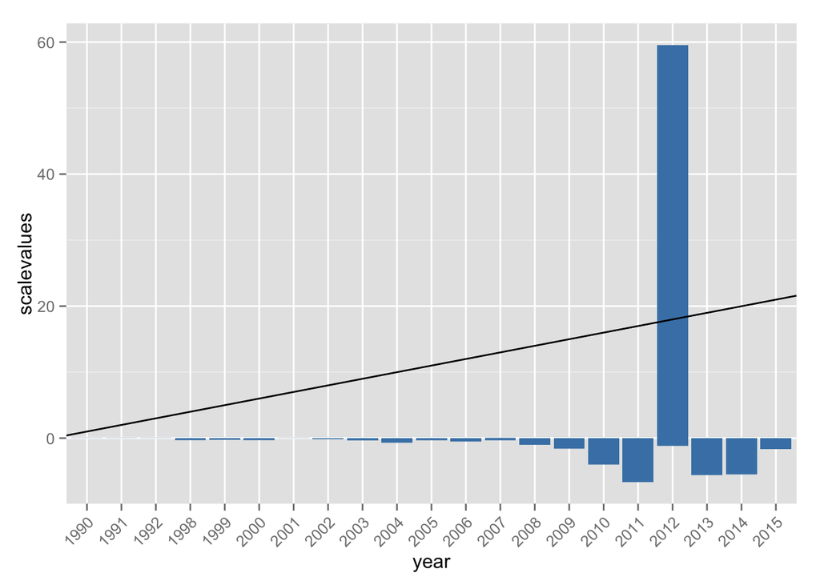

```r
plt <- ggplot(na.omit(haiti), aes(year, scalevalues)) +
  geom_bar(stat='identity', fill = "steelblue") +
  geom_abline(intercept = -2.101609e-18)+
  theme(axis.text.x = element_text(angle = 45, hjust = 1))

plt
```

There was a large spike in 2012, with relative decreases. Haiti can expect the aid amount to stay stable or increase slightly.

### Honduras

```r
q <- data.clean %>% select(transvalue, recipient, transactiondate) %>%
          filter(recipient == "Honduras") %>%
          mutate(year = strftime('%Y', transactiondate))

honduras<- collect(q)

honduras$transvalue <- as.numeric(honduras$transvalue)

honduras$scalevalues <- scale(honduras$transvalue)

mean(honduras$scalevalues)
```

```
## [1] 6.458883e-18
```

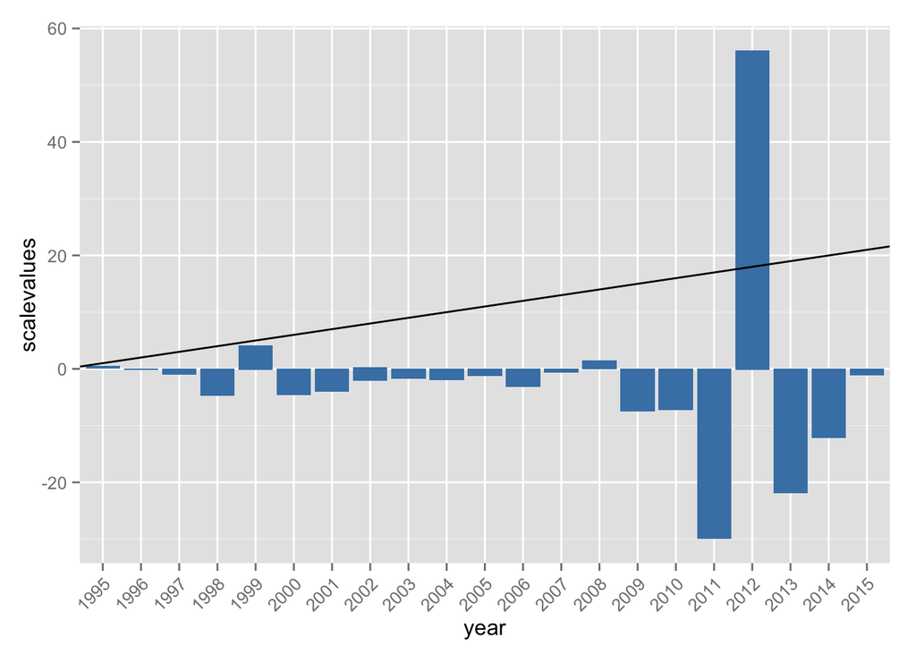

```r
plt <- ggplot(na.omit(honduras), aes(year, scalevalues)) +
  geom_bar(stat='identity', fill = "steelblue") +
  geom_abline(intercept = 6.458883e-18)+
  theme(axis.text.x = element_text(angle = 45, hjust = 1))

plt
```

Honduras had large spike in 2012, with relatively little aid to the country surrounding the spike. Aid amounts have increased since 2013 and the trend will continue due to Honduras’s violence/drug situation and proximity to the United States.

### Kyrgyzstan

```r
q <- data.clean %>% select(transvalue, recipient, transactiondate) %>%
          filter(recipient == "Kyrgyzstan") %>%
          mutate(year = strftime('%Y', transactiondate))

kyrg<- collect(q)

kyrg$transvalue <- as.numeric(kyrg$transvalue)

kyrg$scalevalues <- scale(kyrg$transvalue)

mean(kyrg$scalevalues)
```

```
## [1] 4.177951e-18
```

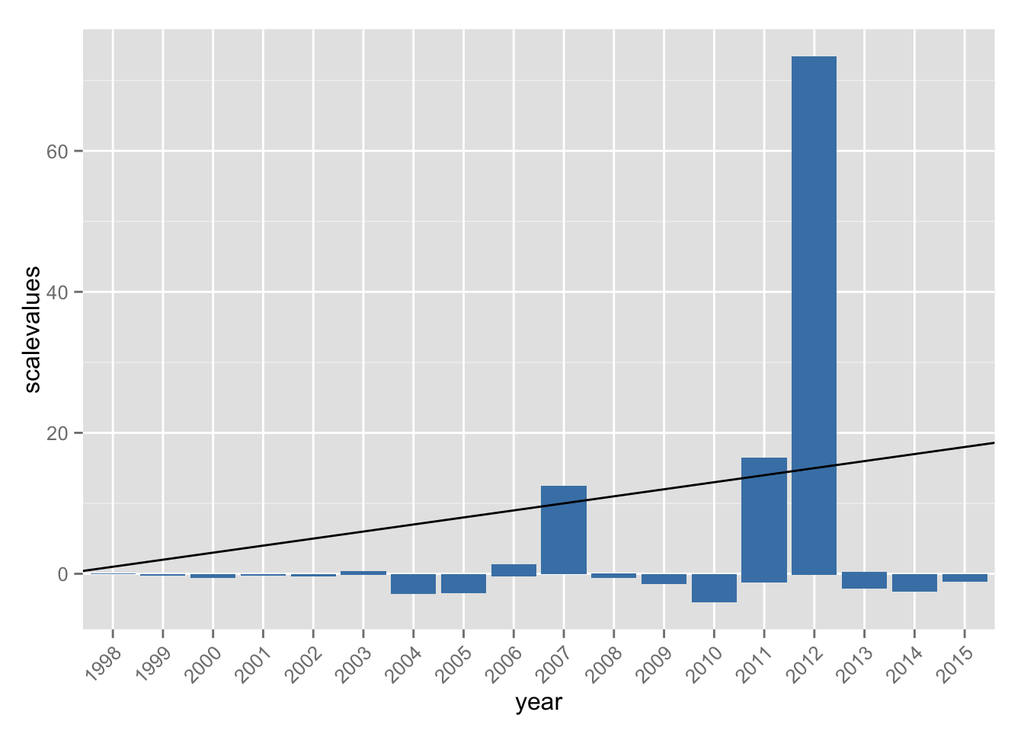

```r
plt <- ggplot(na.omit(kyrg), aes(year, scalevalues)) +
  geom_bar(stat='identity', fill = "steelblue") +
  geom_abline(intercept = 4.177951e-18)+
  theme(axis.text.x = element_text(angle = 45, hjust = 1))

plt
```

Kyrgyzstan had three relative spikes in 2007, 2011, 2012. Besides those spikes aid amounts are relatively similar and not flucutating. Expect the same to occur in 2015 and beyond.

### Laos

```r
q <- data.clean %>% select(transvalue, recipient, transactiondate) %>%
          filter(recipient == "Laos") %>%
          mutate(year = strftime('%Y', transactiondate))

laos<- collect(q)

laos$transvalue <- as.numeric(laos$transvalue)

laos$scalevalues <- scale(laos$transvalue)

mean(laos$scalevalues)
```

```
## [1] 1.091705e-21
```

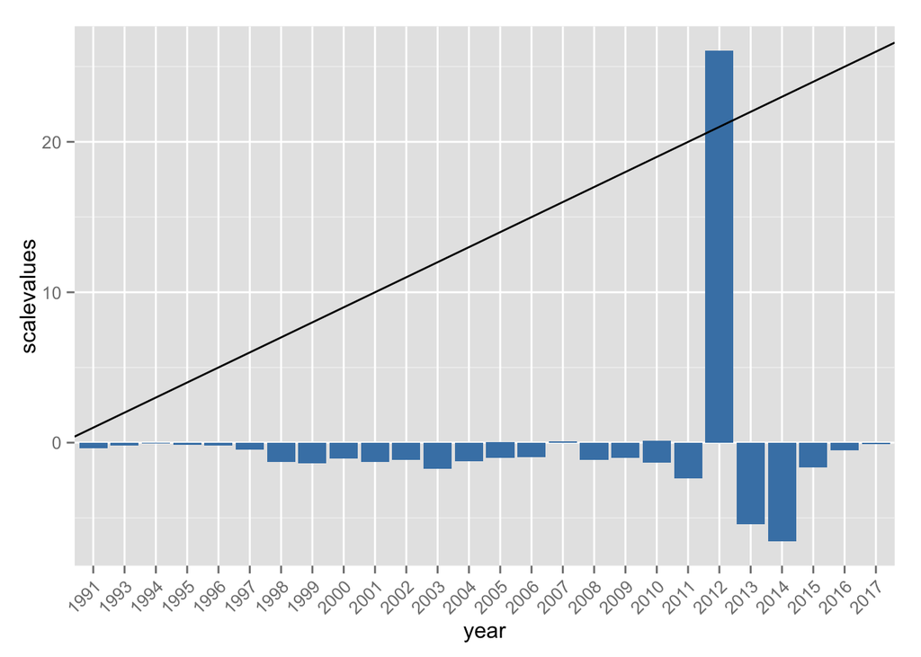

```r
plt <- ggplot(na.omit(laos), aes(year, scalevalues)) +
  geom_bar(stat='identity', fill = "steelblue") +
  geom_abline(intercept =  1.091705e-21)+
  theme(axis.text.x = element_text(angle = 45, hjust = 1))

plt
```

Large spike in 2012, with relative smaller than normal amounts of financial foreign aid in 2013 and 2014. Amount seems to be increasing in 2015 and can expect the amount in 2015 and 2016 to be larger than in 2016 and return back to pre 2012 numbers.

### Madagascar

```r
q <- data.clean %>% select(transvalue, recipient, transactiondate) %>%
          filter(recipient == "Madagascar") %>%
          mutate(year = strftime('%Y', transactiondate))

madagascar<- collect(q)

madagascar$transvalue <- as.numeric(madagascar$transvalue)

madagascar$scalevalues <- scale(madagascar$transvalue)

mean(madagascar$scalevalues)
```

```
## [1] -1.081833e-17
```

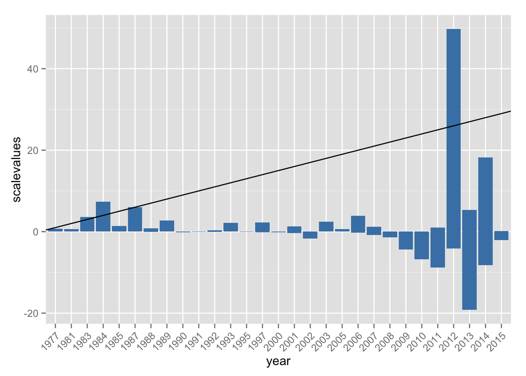

```r
plt <- ggplot(na.omit(madagascar), aes(year, scalevalues)) +
  geom_bar(stat='identity', fill = "steelblue") +
  geom_abline(intercept =  -1.081833e-17)+
  theme(axis.text.x = element_text(angle = 45, hjust = 1))

plt
```

Madagascar has lots of fluctuation with spikes in 2012 and 2014 and a large low in 2013. The last time this pattern occured was 2001-2003. Madagascar is harder to predict, but 2015 and 2016 amount should decreased relative to 2014.

### Malawi

```r
q <- data.clean %>% select(transvalue, recipient, transactiondate) %>%
          filter(recipient == "Malawi") %>%
          mutate(year = strftime('%Y', transactiondate))

malawi<- collect(q)

malawi$transvalue <- as.numeric(malawi$transvalue)

malawi$scalevalues <- scale(malawi$transvalue)

mean(malawi$scalevalues)
```

```
## [1] -5.400044e-18
```

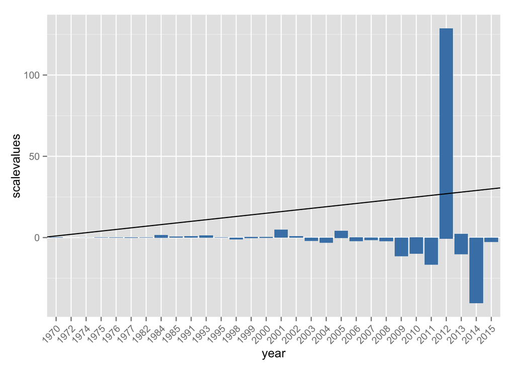

```r
plt <- ggplot(na.omit(malawi), aes(year, scalevalues)) +
  geom_bar(stat='identity', fill = "steelblue") +
  geom_abline(intercept =  -5.400044e-18)+
  theme(axis.text.x = element_text(angle = 45, hjust = 1))

plt
```

Large spike in 2012 with decrease in aid amounts in 2013 and a large decrease in 2014. 2015 should return to relative average amount.

### Nepal

```r
q <- data.clean %>% select(transvalue, recipient, transactiondate) %>%
          filter(recipient == "Nepal") %>%
          mutate(year = strftime('%Y', transactiondate))

nepal <- collect(q)

nepal$transvalue <- as.numeric(nepal$transvalue)

nepal$scalevalues <- scale(nepal$transvalue)

mean(nepal$scalevalues)
```

```
## [1] -2.111368e-18
```

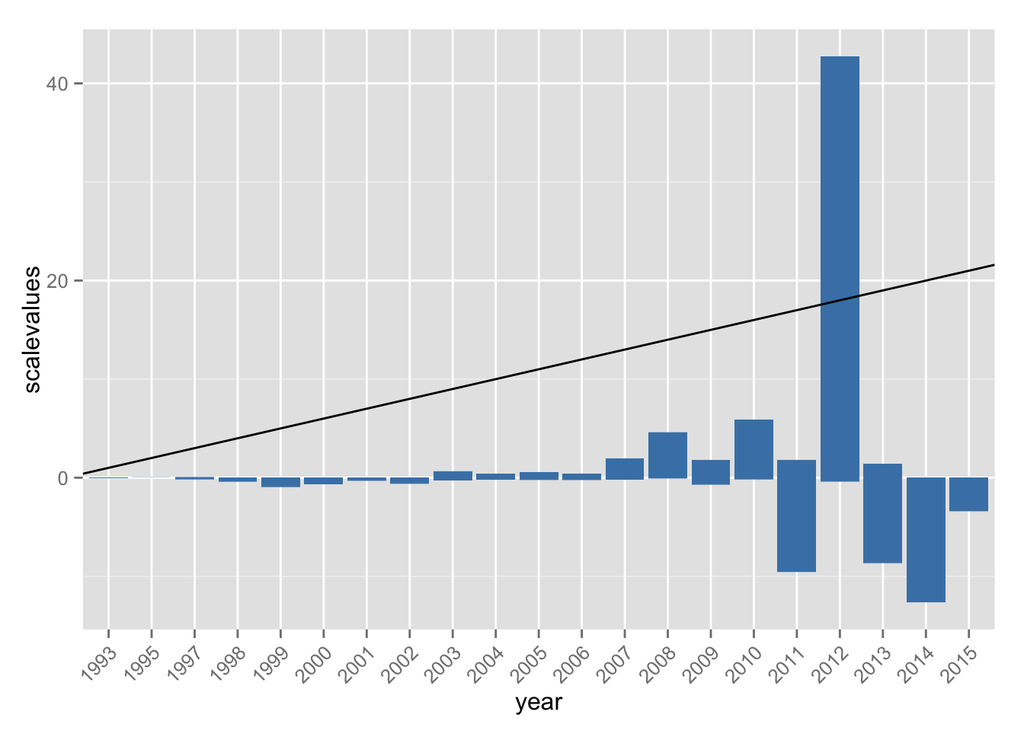

```r
plt <- ggplot(na.omit(nepal), aes(year, scalevalues)) +
  geom_bar(stat='identity', fill = "steelblue") +
  geom_abline(intercept = 2.664344e-18)+
  theme(axis.text.x = element_text(angle = 45, hjust = 1))

plt
```

Nepal had a large amount of aid come in 2012 with a decrease in 2013 and 2014. 2015 and in the near future there will be large spikes in aid because of the recent earthquake. Expect there to be large spikes in 2015 and 2016 with a decrease in 2017.

### Senegal

```r
q <- data.clean %>% select(transvalue, recipient, transactiondate) %>%
          filter(recipient == "Senegal") %>%
          mutate(year = strftime('%Y', transactiondate))

senegal <- collect(q)

senegal$transvalue <- as.numeric(senegal$transvalue)

senegal$scalevalues <- scale(senegal$transvalue)

mean(senegal$scalevalues)
```

```
## [1] -5.378174e-20
```

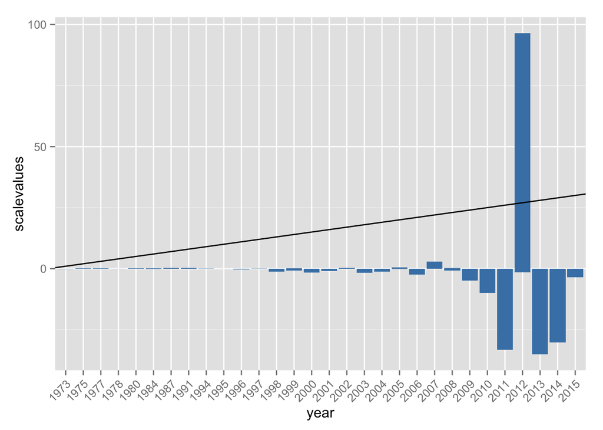

```r
plt <- ggplot(na.omit(senegal), aes(year, scalevalues)) +
  geom_bar(stat='identity', fill = "steelblue") +
  geom_abline(intercept = -5.378174e-20)+
  theme(axis.text.x = element_text(angle = 45, hjust = 1))

plt
```

Large spike in 2012 with major decreases in 2013 and 2014. Expect 2015 to return back to the average small amount.

### Tanzania

```r
q <- data.clean %>% select(transvalue, recipient, transactiondate) %>%
          filter(recipient == "Tanzania United Republic Of") %>%
          mutate(year = strftime('%Y', transactiondate))

tanzania <- collect(q)

tanzania$transvalue <- as.numeric(tanzania$transvalue)

tanzania$scalevalues <- scale(tanzania$transvalue)

mean(tanzania$scalevalues)
```

```
## [1] 8.896276e-19
```

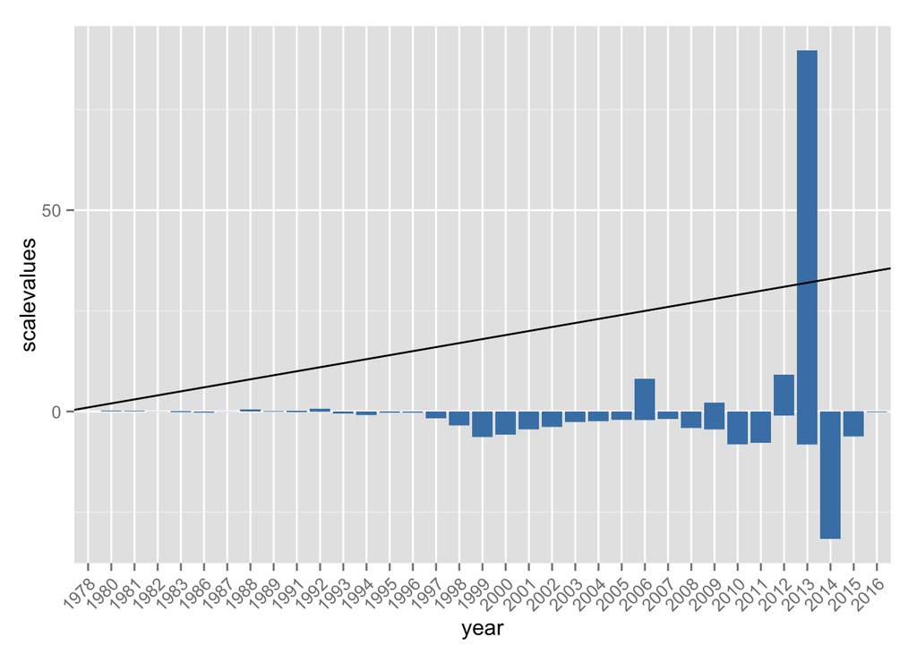

```r
plt <- ggplot(na.omit(tanzania), aes(year, scalevalues)) +
  geom_bar(stat='identity', fill = "steelblue") +
  geom_abline(intercept = 8.896276e-19)+
  theme(axis.text.x = element_text(angle = 45, hjust = 1))

plt
```

### Timor-Leste

```r
q <- data.clean %>% select(transvalue, recipient, transactiondate) %>%
          filter(recipient == "Timor-Leste") %>%
          mutate(year = strftime('%Y', transactiondate))

timor <- collect(q)

timor$transvalue <- as.numeric(timor$transvalue)

timor$scalevalues <- scale(timor$transvalue)

mean(timor$scalevalues)
```

```
## [1] -9.939034e-19
```

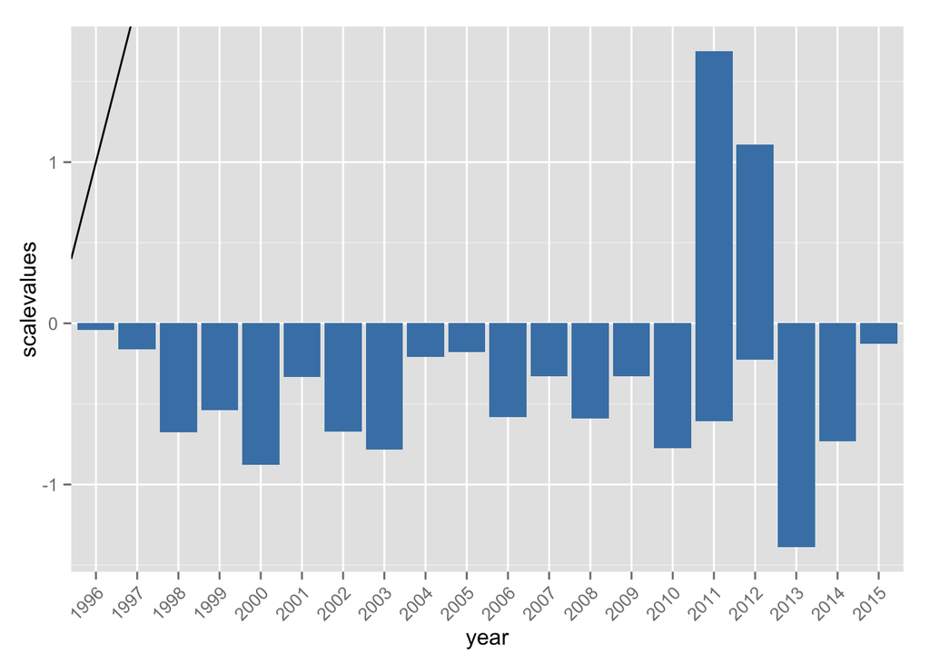

```r
plt <- ggplot(na.omit(timor), aes(year, scalevalues)) +
  geom_bar(stat='identity', fill = "steelblue") +
  geom_abline(intercept = -9.939034e-19)+
  theme(axis.text.x = element_text(angle = 45, hjust = 1))

plt
```

Spike in 2011 and 2012 with decrease in 2013, but an increase in 2014. 2015 should increase, but the amount of aid entering Timor-Leste is relatively small compared to other nations.

### Uganda

```r
q <- data.clean %>% select(transvalue, recipient, transactiondate) %>%
          filter(recipient == "Uganda") %>%
          mutate(year = strftime('%Y', transactiondate))

uganda <- collect(q)

uganda$transvalue <- as.numeric(uganda$transvalue)

uganda$scalevalues <- scale(uganda$transvalue)

mean(uganda$scalevalues)
```

```
## [1] -1.66862e-19
```

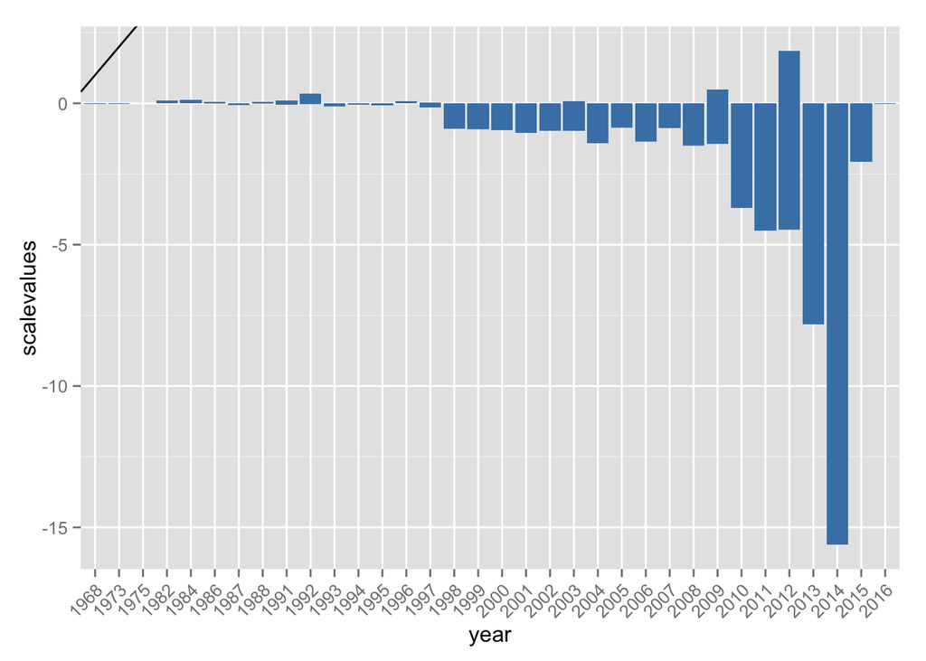

```r
plt <- ggplot(na.omit(uganda), aes(year, scalevalues)) +
  geom_bar(stat='identity', fill = "steelblue") +
  geom_abline(intercept = -1.66862e-19)+
  theme(axis.text.x = element_text(angle = 45, hjust = 1))

plt
```

Uganda there was a large decrease in aid 2013 and 2014. This is due to donors pulling out of Uganda because of the recent government policies targeting Homosexual citizens and foreign workers in the nation. Expect to see an increase compared to 2014, but still relative small number.

# Conclusion

It is hard to predict financial foreign amounts. Financial foreign aid amounts tend to reactive to events in the country i.e. recent earthquake in Nepal or 2010 earthquake in Haiti. The only real way to look at financial foreign aid is that the amounts are increasing and will continue to increase, but it is almost impossible to predict when spikes will occur.